# better_EDA

## TalkingData AdTracking Fraud Detection Challenge

https://www.kaggle.com/c/talkingdata-adtracking-fraud-detection

From *basic_EDA.ipynb* notebook, we have learned that:

1. Data is huge. We need to think about how to manage memory issues
2. All features except click_time are categorical and they are encoded by some unknown rules
3. Click rates vary as a function of time (there are a lot less clicks in some hours)
4. Classification problem is a super imbalanced problem
5. It is also a future prediction problem. We train data in the past and predict click frauds in future. Cross validation strategy will be a little bit different in such a problem

**Notable discussion on Competition Forum:**  
Including feature *ip* in your model will hurt your out-of-sample score.  
And I quote from a kaggler,  
"The pattern of IP assignment in Train does not mimic the one in test. If you go by using IP value as a signal in train, your final test results will be off substantially."

Something fishy going on in feature *ip*:  
**Overall the number of IPs (test OR train): 333168**  
**Number of IPs that are in both (test AND train): 38164**  
**Number of IPs that are in Train and NOT in Test: 239232**  
**Number of IPs that are in Test and NOT in Train: 55772**

This notebook will address concepts drift in feature space

```python
import pandas as pd
import numpy as np
import matplotlib.pyplot as plt

# klearn import
from klearn.eda import SeabornPlot

train_columns = ['ip', 'app', 'device', 'os', 'channel', 'click_time', 'is_attributed']
test_columns = ['ip', 'app', 'device', 'os', 'channel', 'click_time', 'click_id']
dtype = {
    'ip': 'uint32',
    'app': 'uint16',
    'device': 'uint16',
    'os': 'uint16',
    'channel': 'uint16',
    'is_attributed': 'uint16',
    'click_id': 'uint32'
}
# read data
df_train = pd.read_csv(
    filepath_or_buffer="../data/train.csv",
    usecols=train_columns,
    dtype=dtype,
    low_memory=True,
    parse_dates=['click_time'],
    infer_datetime_format=True,
#     skiprows=range(1, 59709852),
#     nrows=50000,
)

# add hour features
df_train['hour'] = df_train['click_time'].dt.hour
```

## Look at the number of clicks of encoded IP at different hours

We will color code the target value:

1. orange dot (0) is *None Fraud*
2. blue dot (1) is *Fraud*

Objective:

1. try to see if there is any signals useful in feature *ip*
2. try to understand how *ip* is encoded

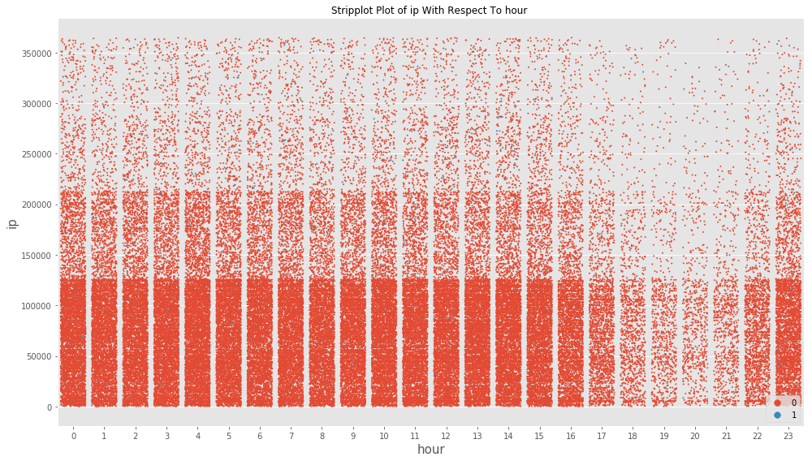

```python
colours = plt.cm.tab10(np.linspace(0, 1, 9))
seaborn_plot = SeabornPlot(size=(14, 8))
seaborn_plot.stripplot(
    x='hour',
    y='ip',
    hue='is_attributed',
    data=df_train,
    **{
        'jitter': 0.4,
        'marker': '.',
        'size': 4,
#         'palette': colours
    }
)
```

Wow, we can see that there seems to be some signals in feature *ip*.

Four strong patterns:

1. *ip* with lower values has much more clicks than *ip* with high values
2. *ip* with higher values are more likely to be fraudulent than *ip* with lower values (more blue dots on top)
3. (my speculation) *ip* is encoded based on number of clicks (or some sort of freqency-based calculation)
4. Again, more clicks in some hours than in 18, 19, 20, 21, 22

## Look at the number of clicks of other features

We will color code the target value:

1. orange dot (0) is *None Fraud*
2. blue dot (1) is *Fraud*

Objective:

1. try to see if those features are encoded in the same way *ip* is encoded

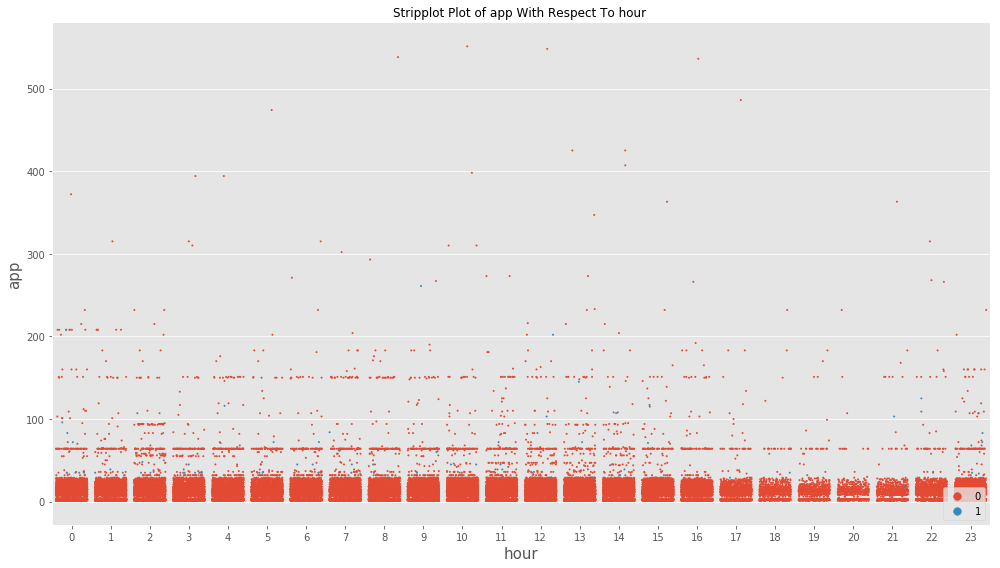

```python
colours = plt.cm.tab10(np.linspace(0, 1, 9))
seaborn_plot = SeabornPlot(size=(14, 8))
seaborn_plot.stripplot(
    x='hour',
    y='app',
    hue='is_attributed',
    data=df_train,
    **{
        'jitter': 0.4,
        'marker': '.',
        'size': 4,
#         'palette': colours
    }
)
```

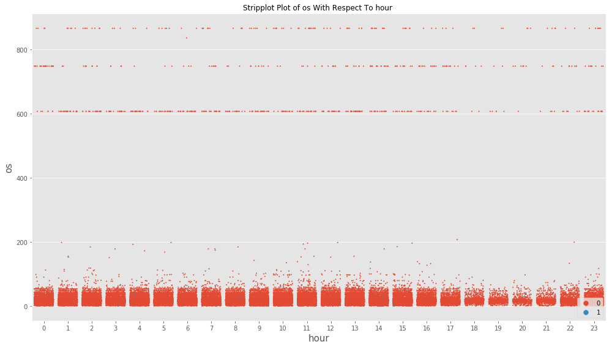

```python
colours = plt.cm.tab10(np.linspace(0, 1, 9))
seaborn_plot = SeabornPlot(size=(14, 8))
seaborn_plot.stripplot(
    x='hour',
    y='os',
    hue='is_attributed',
    data=df_train,
    **{
        'jitter': 0.4,
        'marker': '.',
        'size': 4,
#         'palette': colours
    }
)
```

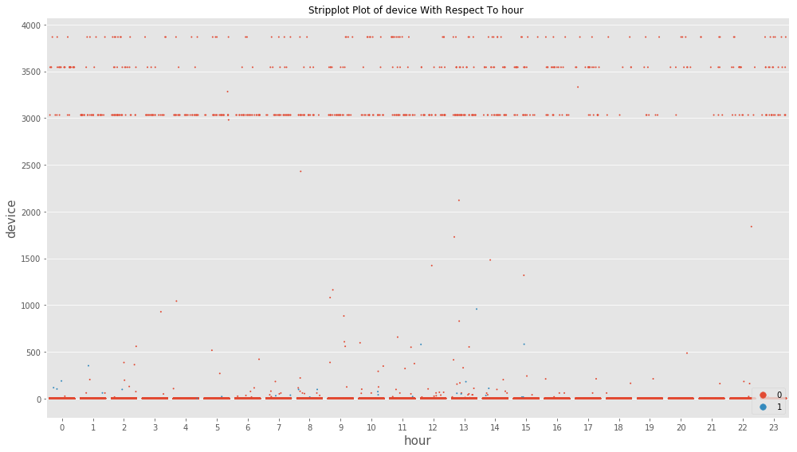

```python
colours = plt.cm.tab10(np.linspace(0, 1, 9))
seaborn_plot = SeabornPlot(size=(14, 8))
seaborn_plot.stripplot(
    x='hour',
    y='device',
    hue='is_attributed',
    data=df_train,
    **{
        'jitter': 0.4,
        'marker': '.',
        'size': 4,
#         'palette': colours
    }
)
```

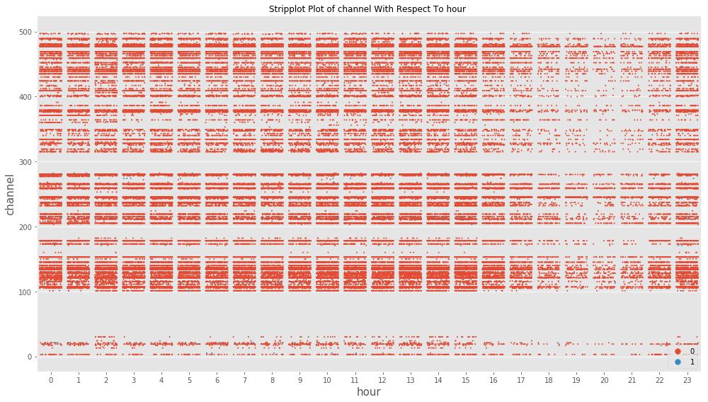

```python
colours = plt.cm.tab10(np.linspace(0, 1, 9))
seaborn_plot = SeabornPlot(size=(14, 8))
seaborn_plot.stripplot(
    x='hour',
    y='channel',
    hue='is_attributed',
    data=df_train,
    **{
        'jitter': 0.4,
        'marker': '.',
        'size': 4,
#         'palette': colours
    }
)
```

Interesting! Other features: *app*, *os*, *device*, and *channel* seem to show some signals. However, they are NOT encoded in the same way that feature *ip* is encoded. At least, these other features are NOT encoded based on freqency of occurence.

Key for feature engineering:

1. Do NOT include origin feature *ip*
2. Decode *ip*, do counts or groupby (other) counts
3. Include *hours* in feature engineering
4. Try to use *ip*, *app*, *os*, *device* to identify each unique user
5. *next_click*